# Chapter3

## Chapter 3 - Analysis

First I read the data from data wrangling part.

```r
library(tidyr)
library(dplyr)
```

```r
library(ggplot2)
setwd("d:/koulujutut/opendata/iods-project/data/")
alc<-read.table("alc.csv",header=TRUE,sep=",")
colnames(alc)
```

```
##  [1] "school"     "sex"        "age"        "address"    "famsize"
##  [6] "Pstatus"    "Medu"       "Fedu"       "Mjob"       "Fjob"
## [11] "reason"     "nursery"    "internet"   "guardian"   "traveltime"
## [16] "studytime"  "failures"   "schoolsup"  "famsup"     "paid"
## [21] "activities" "higher"     "romantic"   "famrel"     "freetime"
## [26] "goout"      "Dalc"       "Walc"       "health"     "absences"
## [31] "G1"         "G2"         "G3"         "alc_use"    "high_use"
```

It gives some basic info about the students. More information about the data here: https://archive.ics.uci.edu/ml/datasets/Student+Performance.

Now we want to see if there’s a connection between alcohol consumption and other variables. I’m looking into 4 variables: romantic, health, G3 and studytime. My hypothesis is that high alcohol consumption decreases the odds to get into romantic relationship, lowers health, takes time off studying, but makes it more effective, i.e. final grade compared to study time is higher, but overall final grades are lower, because the lowest final exam scores probably are from very the highest consumers.

```r
columns<-c("romantic","studytime","health","G3","high_use")
data <- select(alc,one_of(columns))
ggplot
```

[output not shown]

For numeric evaluation, I’ll start with constructing two subtables of table alc: Low alcohol users and high alcohol users.

```r
LU<-subset(data,data$high_use=="FALSE")
HU<-subset(data,data$high_use=="TRUE")
```

```r
mean(LU$G3)
```

```
## [1] 11.73507
```

```r
mean(HU$G3)
```

```
## [1] 10.80702
```

```r
mean(LU$health)
```

```
## [1] 3.518657
```

```r
mean(HU$health)
```

```
## [1] 3.701754
```

```r
mean(LU$G3)
```

```
## [1] 11.73507
```

```r
mean(HU$G3)
```

```
## [1] 10.80702
```

```r
mean(LU$G3)
```

```
## [1] 11.73507
```

```r
mean(HU$G3)
```

```
## [1] 10.80702
```

```r
sum(LU$romantic=="yes")/sum(LU$romantic=="no")
```

```
## [1] 0.4888889
```

```r
sum(HU$romantic=="yes")/sum(HU$romantic=="no")
```

```
## [1] 0.4074074
```

Graphics for high consumption

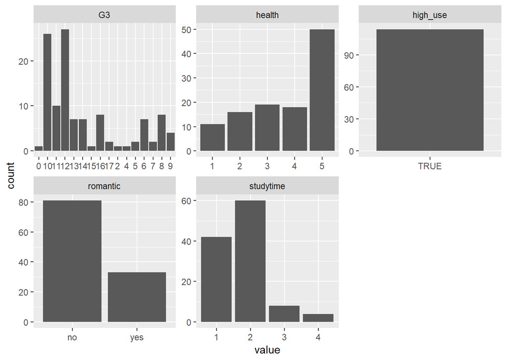

```r
gather(HU) %>% ggplot(aes(value)) + facet_wrap("key", scales = "free") + geom_bar()
```

Graphics for low consumption

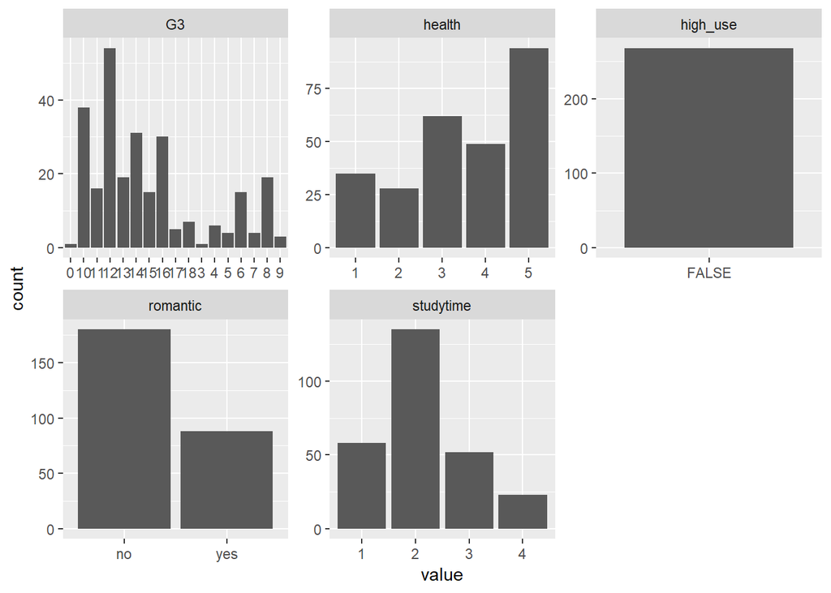

```r
gather(LU) %>% ggplot(aes(value)) + facet_wrap("key", scales = "free") + geom_bar()
```

```r
a<-glm(high_use ~ health + G3 + studytime+romantic, data = alc, family = "binomial")
summary(a)
```

```
##
## Call:
## glm(formula = high_use ~ health + G3 + studytime + romantic,
##     family = "binomial", data = alc)
##
## Deviance Residuals:
##     Min       1Q   Median       3Q      Max
## -1.4142  -0.8685  -0.6932   1.2799   2.1944
##
## Coefficients:
##             Estimate Std. Error z value Pr(>|z|)
## (Intercept)  0.78172    0.59239   1.320 0.186967
## health       0.06049    0.08355   0.724 0.469022
## G3          -0.06491    0.03560  -1.823 0.068302 .
## studytime   -0.54302    0.15461  -3.512 0.000444 ***
## romanticyes -0.20473    0.25375  -0.807 0.419769
## ---
## Signif. codes:  0 '***' 0.001 '**' 0.01 '*' 0.05 '.' 0.1 ' ' 1
##
## (Dispersion parameter for binomial family taken to be 1)
##
##     Null deviance: 465.68  on 381  degrees of freedom
## Residual deviance: 443.88  on 377  degrees of freedom
## AIC: 453.88
##
## Number of Fisher Scoring iterations: 4
```

We see that the only statistically significant result is study time decreasing when alcohol consumption increases.

```r
coef(a)
```

```
## (Intercept)      health          G3   studytime romanticyes
##  0.78172332  0.06049458 -0.06490750 -0.54301860 -0.20472927
```

We get odds ratios by using the coefficients as exponent.

```r
exp(summary(a)$coefficients[,1])
```

```
## (Intercept)      health          G3   studytime romanticyes
##   2.1852349   1.0623618   0.9371541   0.5809918   0.8148679
```

and lower bounds for 95% condidence interval using standard error and correct values for normal distribution.

```r
exp((summary(a)$coefficients[,1])+summary(a)$coefficients[,2]*qnorm(0.025))
```

```
## (Intercept)      health          G3   studytime romanticyes
##   0.6843112   0.9018958   0.8739857   0.4291092   0.4955606
```

Similiarly upper bounds.

```r
exp((summary(a)$coefficients[,1])+summary(a)$coefficients[,2]*qnorm(0.975))
```

```
## (Intercept)      health          G3   studytime romanticyes
##   6.9781866   1.2513781   1.0048882   0.7866331   1.3399161
```

We once again see that only study time has it’s whole 95% confidence interval below/over 1 and it’s the only statistically significant result.

```r
m <- glm(high_use ~ studytime, data = alc, family = "binomial")
probabilities <- predict(m, type = "response")
alc <- mutate(alc, probability = probabilities)
alc <- mutate(alc, prediction = probability > 0.5)
select(alc, studytime, high_use, probability, prediction) %>% tail(10)
```

```
##     studytime high_use probability prediction
## 373         1    FALSE   0.4299752      FALSE
## 374         1     TRUE   0.4299752      FALSE
## 375         3    FALSE   0.1842725      FALSE
## 376         1    FALSE   0.4299752      FALSE
## 377         3    FALSE   0.1842725      FALSE
## 378         2    FALSE   0.2921823      FALSE
## 379         2    FALSE   0.2921823      FALSE
## 380         2    FALSE   0.2921823      FALSE
## 381         1     TRUE   0.4299752      FALSE
## 382         1     TRUE   0.4299752      FALSE
```

```r
table(high_use = alc$high_use, prediction = alc$prediction)
```

```
##         prediction
## high_use FALSE
##    FALSE   268
##    TRUE    114
```

It seems that my model is retarded and assumes that no one consumes alcohol.

```r
loss_func <- function(class, prob) {
  n_wrong <- abs(class - prob) > 0.5
  mean(n_wrong)
}
loss_func(class = alc$high_use, prob = alc$probability)
```

```
## [1] 0.2984293
```

My model is a very simple guessing strategy, so it performs like one.